# Relatório Técnico: Seleção de Famílias Pró-Produtivas de Cana-de-Açúcar via Aprendizado de Máquina

Trabalho Final - Disciplina EST 792

Lucas Pereira Belo

Junho de 2026

# 1. Introduction and Contextualization of the Experiment

This report presents the development and evaluation of predictive models applied to a sugarcane experiment conducted under a Randomized Block Design (RBD) at the Oratórios experimental station, MG. The study evaluates **60 families** distributed in **4 blocks (replications)**, totaling **240 experimental plots**. The original data were summarized at the mean level per family in the file `dd3.xlsx`, totaling 60 analytical entries.

The central objective is to compare statistical learning techniques for **Regression** (predicting continuous productivity in TSH) and **Classification** (dichotomous sorting based on the mean) problems.

# 2. Preparation and Exploratory Data Analysis (EDA)

## 2.1 Import and Structuring

```r
# Leitura e reestruturação do dataframe original
dd3 <- read_excel("dd3.xlsx")

dados <- dd3 %>%
  select(
    Family = Familia,
    SN     = NC,        # Número médio de colmos por parcela
    TSH    = TCH.x,     # Toneladas de colmos por hectare
    SD     = DIAMETRO,  # Diâmetro médio do colmo
    SH     = ALTURA,    # Altura média do colmo
    R      = Red,       # Reflectância na banda do Vermelho
    G      = Green,     # Reflectância na banda do Verde
    B      = Blue,      # Reflectância na banda do Azul
    VARI   = VARI,      # Visible Atmospherically Resistant Index
    GLI    = GLI,       # Green Leaf Index
    NGRDI  = NGRDI      # Normalized Green Red Difference Index
  )

dados$Family <- as.factor(dados$Family)
```

## Graphical Correlation Analysis

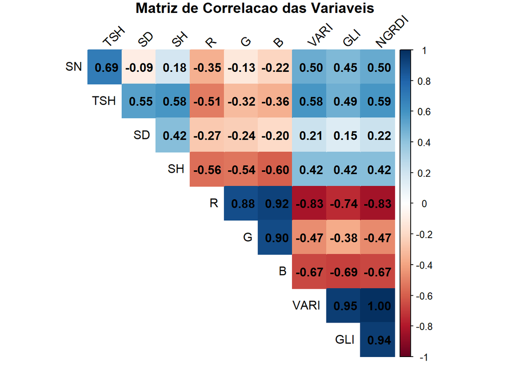

```r
# Seleciona apenas as variáveis numéricas
dados_num <- dados %>% select(-Family)

# Calcula a matriz de correlação (Pearson)
matriz_corr <- cor(dados_num, use = "complete.obs")

corrplot(matriz_corr,
         method = "color",       # Usa cores para representar a força
         type = "upper",         # Mostra só a metade de cima da matriz
         addCoef.col = "black",  # Adiciona os números da correlação em preto
         tl.col = "black",       # Cor do texto dos eixos
         tl.srt = 45,            # Rotaciona os nomes das variáveis em 45 graus
         diag = FALSE,           # Tira a diagonal principal (que é sempre 1)
         title = "Matriz de Correlacao das Variaveis",
         mar = c(0,0,1,0))       # Ajusta a margem para o título caber direitinho
```